# act_report

## Report: act_report_Suleman_Aneru

The data visualization in this project would be used to answer the following questions

1. Has there been an increase in the interactions this twitter account gets from viewers?
2. Is there a correlation between the ratings dogs get to how much people like the tweets and retweet them?
3. Is there a direct relationship between the retweets and favorites?
4. What dog breeds are the most popularly featured in this twitter account?
5. What dog breeds have the highest ratings?
6. What dog breeds have the highest retweets?
7. What dog breeds have the highest likes?

These questions would be answered after plotting some charts with the cleaned data

```python
import pandas as pd
import numpy as np
import matplotlib.pyplot as plt
import seaborn as sns

%matplotlib inline
```

```python
df123_clean = pd.read_csv('twitter_archive_master.csv')
```

```python
df123_clean.head()
```

|  | tweet_id | timestamp | source | text | rating_numerator | rating_denominator | retweet_count | favorite_count | dog_breed |
| --- | --- | --- | --- | --- | --- | --- | --- | --- | --- |
| 0 | 892177421306343426 | 2017-08-01 00:17:27+00:00 | Twitter for iPhone | This is Tilly. She's just checking pup on you.... | 13 | 10 | 5280 | 29255 | Chihuahua |
| 1 | 891815181378084864 | 2017-07-31 00:18:03+00:00 | Twitter for iPhone | This is Archie. He is a rare Norwegian Pouncin... | 12 | 10 | 3466 | 21986 | Chihuahua |
| 2 | 891689557279858688 | 2017-07-30 15:58:51+00:00 | Twitter for iPhone | This is Darla. She commenced a snooze mid meal... | 13 | 10 | 7199 | 36819 | Labrador Retriever |
| 3 | 891327558926688256 | 2017-07-29 16:00:24+00:00 | Twitter for iPhone | This is Franklin. He would like you to stop ca... | 12 | 10 | 7722 | 35212 | Basset |
| 4 | 891087950875897856 | 2017-07-29 00:08:17+00:00 | Twitter for iPhone | Here we have a majestic great white breaching ... | 13 | 10 | 2590 | 17759 | Chesapeake Bay Retriever |

```python
df123_clean.dtypes
```

```
tweet_id               int64
timestamp             object
source                object
text                  object
rating_numerator       int64
rating_denominator     int64
retweet_count          int64
favorite_count         int64
dog_breed             object
dtype: object
```

```python
df123_clean['timestamp'] = pd.to_datetime(df123_clean['timestamp'])
df123_clean['dog_breed'] = pd.Categorical(df123_clean.dog_breed)
```

```python
df123_clean.dtypes
```

```
tweet_id                            int64
timestamp             datetime64[ns, UTC]
source                             object
text                               object
rating_numerator                    int64
rating_denominator                  int64
retweet_count                       int64
favorite_count                      int64
dog_breed                        category
dtype: object
```

## Question 1

Has there been an increase in the interactions this twitter account gets from viewers?

We would answer this by plotting a time series of retweet counts as well as favorite counts and see how the trends of retweets and likes have been over time

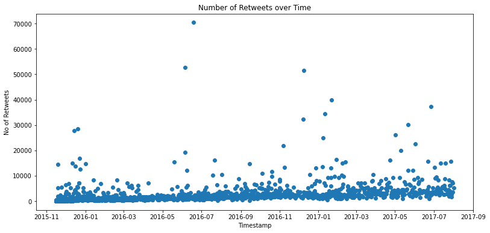

```python
x = df123_clean['timestamp']
y = df123_clean['retweet_count']
plt.rcParams["figure.figsize"] = (13,6)
plt.scatter(x, y);
plt.xlabel("Timestamp")
plt.ylabel("No of Retweets")
plt.title('Number of Retweets over Time');
```

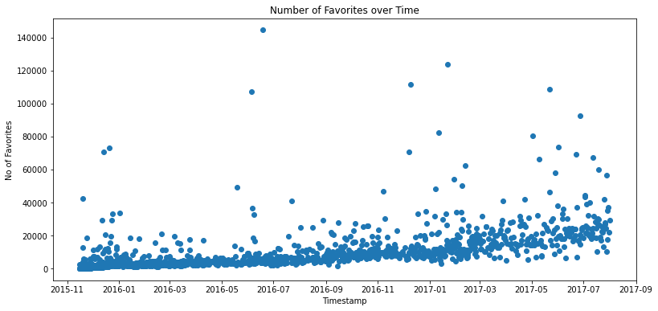

```python
x = df123_clean['timestamp']
y = df123_clean['favorite_count']
plt.rcParams["figure.figsize"] = (13,6)
plt.scatter(x, y);
plt.xlabel("Timestamp")
plt.ylabel("No of Favorites")
plt.title('Number of Favorites over Time');
```

## Question 2

Is there a correlation between the ratings dogs get to how much people like the tweets and retweet them?

We would answer this by plotting the dog ratings against favorite counts and retweet counts

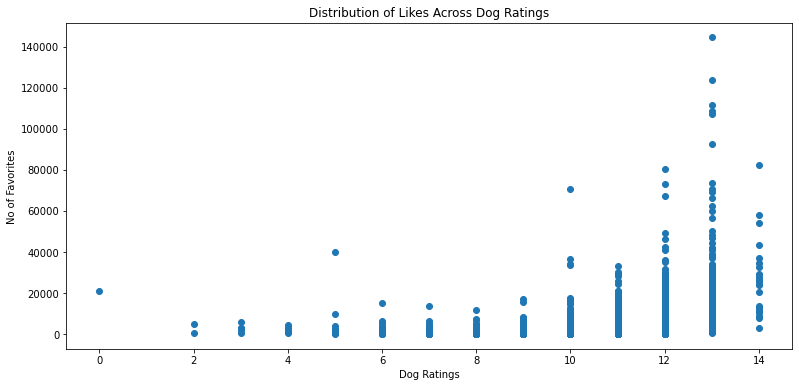

```python
x = df123_clean['rating_numerator']
y = df123_clean['favorite_count']
plt.rcParams["figure.figsize"] = (13,6)
plt.scatter(x, y);
plt.xlabel("Dog Ratings")
plt.ylabel("No of Favorites")
plt.title('Distribution of Likes Across Dog Ratings');
```

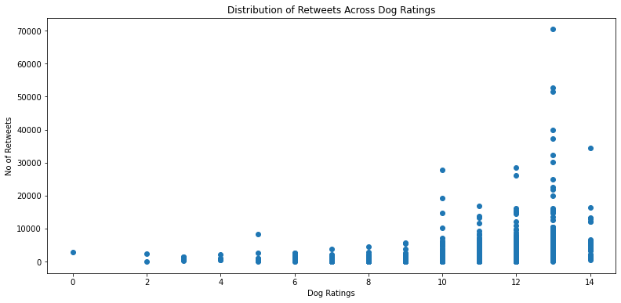

```python
x = df123_clean['rating_numerator']
y = df123_clean['retweet_count']
plt.rcParams["figure.figsize"] = (13,6)
plt.scatter(x, y);
plt.xlabel("Dog Ratings")
plt.ylabel("No of Retweets")
plt.title('Distribution of Retweets Across Dog Ratings');
```

## Question 3

Is there a direct relationship between retweets and likes?

We would answer this by plotting both against each other.

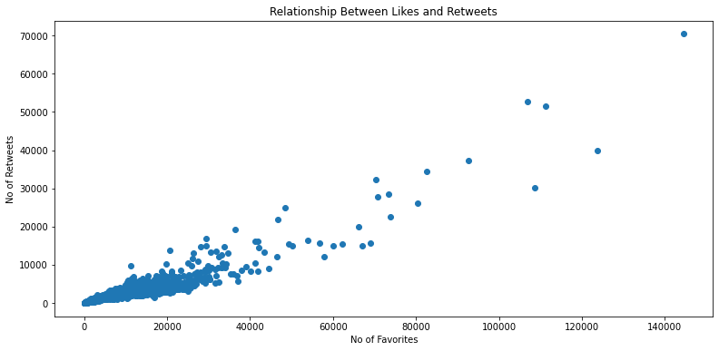

```python
x = df123_clean['favorite_count']
y = df123_clean['retweet_count']
plt.rcParams["figure.figsize"] = (13,6)
plt.scatter(x, y);
plt.xlabel("No of Favorites")
plt.ylabel("No of Retweets")
plt.title('Relationship Between Likes and Retweets');
```

```python
df123_clean.describe()
```

|  | tweet_id | rating_numerator | rating_denominator | retweet_count | favorite_count |
| --- | --- | --- | --- | --- | --- |
| count | 1.673000e+03 | 1673.000000 | 1673.0 | 1673.000000 | 1673.000000 |
| mean | 7.390337e+17 | 10.830843 | 10.0 | 2277.465033 | 7989.488344 |
| std | 6.797545e+16 | 1.780263 | 0.0 | 4146.155133 | 11770.922392 |
| min | 6.660209e+17 | 0.000000 | 10.0 | 11.000000 | 66.000000 |
| 25% | 6.773315e+17 | 10.000000 | 10.0 | 514.000000 | 1800.000000 |
| 50% | 7.127178e+17 | 11.000000 | 10.0 | 1126.000000 | 3659.000000 |
| 75% | 7.931506e+17 | 12.000000 | 10.0 | 2581.000000 | 9886.000000 |
| max | 8.921774e+17 | 14.000000 | 10.0 | 70432.000000 | 144415.000000 |

## Question 4

What dog breeds are the most popularly featured in this twitter account?

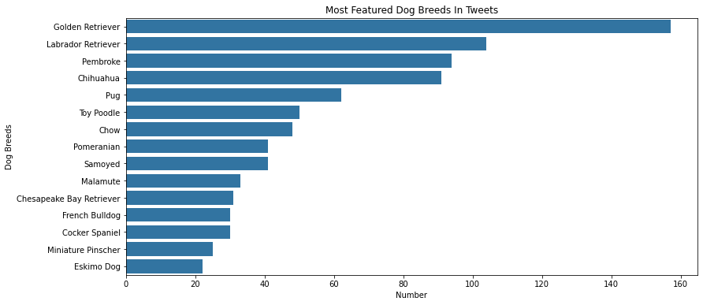

```python
# 15 dog breeds featured the most in tweets

w = df123_clean['dog_breed'].value_counts().index[:15]
base_color = sns.color_palette()[0]
sns.countplot(data = df123_clean, y = df123_clean['dog_breed'], color = base_color, order = w);
plt.xlabel("Number")
plt.ylabel("Dog Breeds")
plt.title('Most Featured Dog Breeds In Tweets');
```

## Question 5

What dog breeds have the highest ratings?

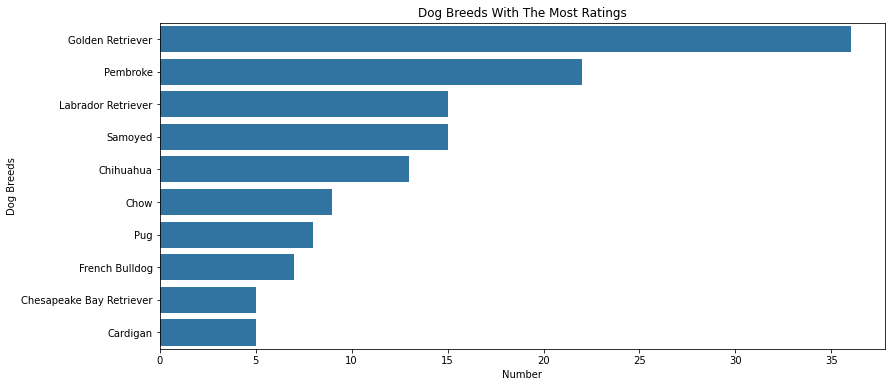

```python
# A rating above the 75% percentile of 12 has been selected as the highest ratings for this analysis

df_top_ratings = df123_clean[df123_clean['rating_numerator'] > 12]
w = df_top_ratings['dog_breed'].value_counts().index[:10]
base_color = sns.color_palette()[0]
sns.countplot(data = df_top_ratings, y = df_top_ratings['dog_breed'], color = base_color, order = w);
plt.xlabel("Number")
plt.ylabel("Dog Breeds")
plt.title('Dog Breeds With The Most Ratings');
```

## Question 6

What dog breeds have the highest retweets?

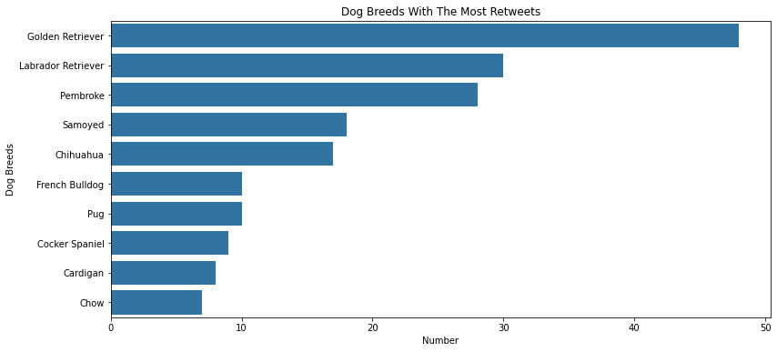

```python
# A rating above the 75% percentile of 2581retweets has been selected as the benchmark for the highest retweets in this analysis

df_top_retweets = df123_clean[df123_clean['retweet_count'] > 3000]
w = df_top_retweets['dog_breed'].value_counts().index[:10]
base_color = sns.color_palette()[0]
sns.countplot(data = df_top_retweets, y = df_top_retweets['dog_breed'], color = base_color, order = w);
plt.xlabel("Number")
plt.ylabel("Dog Breeds")
plt.title('Dog Breeds With The Most Retweets');
```

## Question 7

What dog breeds have the highest likes?

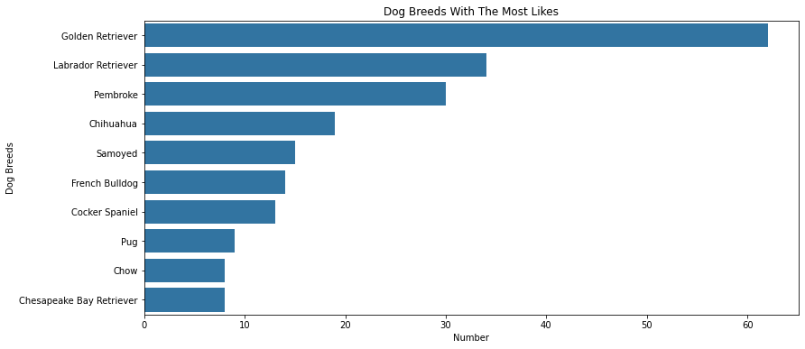

```python
# A rating above the 75% percentile of 9886likes has been selected as the benchmark for the highest favorites in this analysis

df_top_favorites = df123_clean[df123_clean['favorite_count'] > 10000]
w = df_top_favorites['dog_breed'].value_counts().index[:10]
base_color = sns.color_palette()[0]
sns.countplot(data = df_top_favorites, y = df_top_favorites['dog_breed'], color = base_color, order = w);
plt.xlabel("Number")
plt.ylabel("Dog Breeds")
plt.title('Dog Breeds With The Most Likes');
```

## Conclusions and Summary of Results

From the charts above, we can infer that this twitter account has received a steady increase in audience engagements as the number of retweets and likes enjoyed a gradual increase for the period under review

Additionally, it is observed that there is a very strong and positive correlation between the number of retweets and the number of likes each tweet gets. The higher the retweet, the higher the likes.

Furthermore, it can be seem that the most breeds of dogs featured in the tweets we reviewed are the Golden Retriever, Labrador Retriever, Pembroke, Chihuahua and Pug. It was also observed that all the above mentioned breeds of dogs were the dogs with the highest ratings, most retweets and most likes except for the Pug which was replaced by the Samoyed breed in the top 5.

In conclusion, this has been a worthwhile project in understanding the entire process of data wrangling and creating visualizations from which meaningful insights can be drawn